# Age and dementia prediction from RMI data

```python
import numpy as np
import matplotlib.pyplot as plt
import pandas as pd

from ipywidgets import interact
import ipywidgets as widgets

from nilearn.input_data import NiftiMasker, NiftiLabelsMasker
from nilearn.plotting import plot_stat_map, show
from nilearn.mass_univariate import permuted_ols

from sklearn.svm import SVR
from sklearn.feature_selection import VarianceThreshold, SelectKBest, f_regression
from sklearn.pipeline import Pipeline
from sklearn.cross_validation import cross_val_score, train_test_split
from sklearn.utils import check_random_state
```

```python
n_subjects = 403 #The whole dataset
training_part = .75
```

## Methodology

We use the MMSE test to quantify the mental health of patients. $ MMSE > 25 $ corresponds to normal scores, whereas smaller ones are generaly considered as a dementia symptom.

- First we have to establish the data coherence inside the dataset, and to clean the data
- Then we can provide a statistical analysis of the data
- Finaly we can train and make predictions with a model

Some of the code is extracted from :

http://nilearn.github.io/auto_examples/02_decoding/plot_oasis_vbm.html#sphx-glr-auto-examples-02-decoding-plot-oasis-vbm-py

Links:

- http://nilearn.github.io/modules/reference.html#module-nilearn.datasets
- http://nilearn.github.io/modules/generated/nilearn.datasets.fetch_oasis_vbm.html#nilearn.datasets.fetch_oasis_vbm
- http://nilearn.github.io/modules/generated/nilearn.datasets.fetch_atlas_harvard_oxford.html#nilearn.datasets.fetch_atlas_harvard_oxford

## Datasets

```python
from nilearn import datasets

# MRI patients data
oasis_dataset = datasets.fetch_oasis_vbm(n_subjects=n_subjects)
gray_matter_map_filenames = oasis_dataset.gray_matter_maps
oasis_infos_df = pd.DataFrame(oasis_dataset.ext_vars)
```

```python
# Data cleaning up
oasis_infos_df.id = oasis_infos_df.id.str.decode("utf-8")
oasis_infos_df.mf = oasis_infos_df.mf.str.decode("utf-8").astype('category')
oasis_infos_df.hand = oasis_infos_df.hand.str.decode("utf-8").astype('category')
oasis_infos_df = oasis_infos_df.drop(labels='delay', axis=1)
```

```python
masker = NiftiMasker(
    standardize=False,
    smoothing_fwhm=2,
    memory='nilearn_cache')
oasis_voxel_series = masker.fit_transform(gray_matter_map_filenames)
```

```python
# Splitting the data into training and recall data
random_state = check_random_state(42)
training_voxel_series, recall_voxel_series, age_train, age_recall = \
    train_test_split(oasis_voxel_series,
                     oasis_infos_df.age,
                     train_size=training_part,
                     random_state=random_state)
```

## Dataset Coherence

```python
oasis_infos_df.head()
```

|  | id | mf | hand | age | educ | ses | mmse | cdr | etiv | nwbv | asf |
| --- | --- | --- | --- | --- | --- | --- | --- | --- | --- | --- | --- |
| 0 | OAS1_0001_MR1 | F | R | 74 | 2 | 3 | 29 | 0.0 | 1344 | 0.743 | 1.306 |
| 1 | OAS1_0002_MR1 | F | R | 55 | 4 | 1 | 29 | 0.0 | 1147 | 0.810 | 1.531 |
| 2 | OAS1_0003_MR1 | F | R | 73 | 4 | 3 | 27 | 0.5 | 1454 | 0.708 | 1.207 |
| 3 | OAS1_0004_MR1 | M | R | 28 | -1 | -1 | -1 | NaN | 1588 | 0.803 | 1.105 |
| 4 | OAS1_0005_MR1 | M | R | 18 | -1 | -1 | -1 | NaN | 1737 | 0.848 | 1.010 |

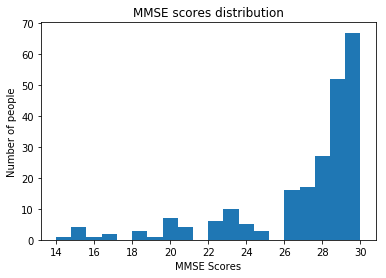

```
There are 226 patients submitted to the mmse test.
However 177 haven't been tested.
```

```python
tested_patients = oasis_infos_df.mmse >= 0
oasis_infos_df[tested_patients].mmse.plot.hist(bins=20)
plt.xlabel("MMSE Scores")
plt.ylabel("Number of people")
plt.title("MMSE scores distribution")
plt.show()

print("There are {} patients submitted to the mmse test."\
      .format(oasis_infos_df[tested_patients].mmse.count()))
print("However {} haven't been tested."\
      .format(oasis_infos_df[~tested_patients].mmse.count()))
```

We only take into consideration the patients that have been tested.

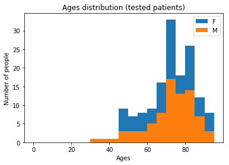

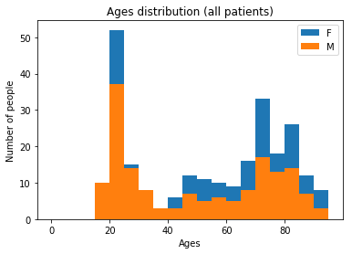

```python
oasis_infos_df[tested_patients].groupby("mf").age.plot.hist(bins=np.arange(0, 100, 5),
                                          stacked=True, legend=True)
plt.xlabel("Ages")
plt.ylabel("Number of people")
plt.title("Ages distribution (tested patients)")
plt.show()

oasis_infos_df.groupby("mf").age.plot.hist(bins=np.arange(0, 100, 5),
                                     stacked=True, legend=True)
plt.xlabel("Ages")
plt.ylabel("Number of people")
plt.title("Ages distribution (all patients)")
plt.show()
```

As we can see, **young patients haven't been systematicaly submited to the tests**.

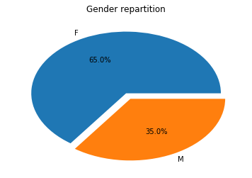

```python
oasis_infos_df[tested_patients].groupby('mf').mf.count().plot\
                               .pie(explode=(0, 0.1),
                                    autopct='%1.1f%%')
plt.ylabel('')
plt.title("Gender repartition")
plt.show()
```

## Statistical analysis

```python
age_limit = 60
youngs = oasis_infos_df.age <= age_limit
dement = np.logical_and(oasis_infos_df.mmse <= 25, tested_patients)
healthy_elders = np.logical_and(~youngs, ~ dement)
```

### Neural density mean : a naïve approach.

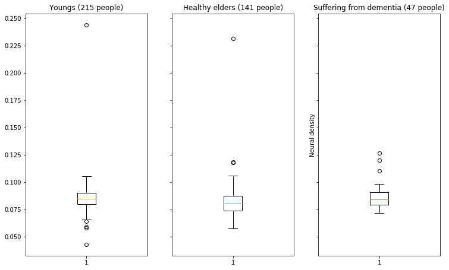

```python
fig, axes = plt.subplots(ncols=3, sharey=True)
fig.set_size_inches(12.5, 7.5)
#pylab.ylim([0.2,0.7])
plt.ylabel("Neural density")
plt.title("Neural density in hippocampus")

axes[0].boxplot(oasis_voxel_series[youngs].mean(axis=1).reshape((-1)))
axes[1].boxplot(oasis_voxel_series[healthy_elders].mean(axis=1).reshape((-1)))
axes[2].boxplot(oasis_voxel_series[dement].mean(axis=1).reshape((-1)))

axes[0].set_title('Youngs ({} people)'\
                  .format(sum(youngs)))
axes[1].set_title('Healthy elders ({} people)'\
                  .format(sum(healthy_elders)))
axes[2].set_title('Suffering from dementia ({} people)'\
                  .format(sum(dement)))
plt.show()
```

Furthermore, the mean neural density of young is slightly better than for elder people.

### Exploiting the area atlas

Now we will try to find the areas where there is the more important difference of density between the healthy subject and those who suffer from dementia.

To achieve that, we calculate the neural density RMS in the dataset to extract to most valuable voxels (i.e. where the RMS is maximum).

```python
voxelwise_mean = oasis_voxel_series.mean(axis=0).reshape((1, -1))
voxelwise_rms = np.sum((oasis_voxel_series - voxelwise_mean)**2, axis=0)
sorted_voxels = sorted(enumerate(voxelwise_rms), key=lambda x:x[1], reverse=True)
```

```python
# Most valuables voxels
pd.DataFrame(sorted_voxels[:5], columns=["Voxel index", "RMS"])
```

|  | Voxel index | RMS |
| --- | --- | --- |
| 0 | 617904 | 78.837067 |
| 1 | 290396 | 77.710297 |
| 2 | 290305 | 77.061989 |
| 3 | 617813 | 76.158211 |
| 4 | 597794 | 75.473068 |

```python
# Least valuable voxels
pd.DataFrame(sorted_voxels[-5:], columns=["Voxel index", "RMS"])
```

|  | Voxel index | RMS |
| --- | --- | --- |
| 0 | 3185 | 6.046246e-09 |
| 1 | 3549 | 5.932095e-09 |
| 2 | 3367 | 5.896388e-09 |
| 3 | 3458 | 5.820567e-09 |
| 4 | 0 | 1.078960e-10 |

## Using Regression

```python
def classifying(k):
    # Vector classification using a linear kernel (supervised learning)
    svr = SVR(kernel='linear')
    # Removing voxels with low variance between subjects
    variance_threshold = VarianceThreshold(threshold=0.01)
    #Using analysis of variance (anova) feature selection
    feature_selection = SelectKBest(f_regression, k) # /!!!!!!!!!!!!!!!\ k VERY IMPORTANT : TO DISCUSS
    #Instructions for the training
    anova_svr = Pipeline([
                          ('variance_threshold', variance_threshold),
                          ('anova', feature_selection),
                          ('svr', svr)])\
                        .fit(training_voxel_series, age_train)
    return anova_svr, svr, feature_selection, variance_threshold

def classifying_predictor(*args):
    return classifying(*args)[0]

def test(classifyer, dataset=recall_voxel_series, ages=age_recall):
    return np.abs(classifyer.predict(dataset) - ages).mean()
```

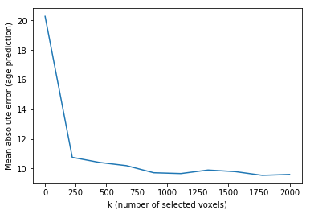

```python
k_values=np.linspace(1, 2000, 10, dtype=int)
classifyers = np.vectorize(classifying_predictor)(k_values)
errors = np.vectorize(test)(classifyers)
plt.plot(k_values, errors)
plt.xlabel("k (number of selected voxels)")
plt.ylabel("Mean absolute error (age prediction)")
plt.show()
```

```python
selected_classifyer = classifyers[-1]
# Test over the training set
age_pred = np.abs(selected_classifyer.predict(training_voxel_series) - age_train).mean()
print("Mean age error of the prediction on the training dataset : {}".format(age_pred))
# Test prediction over the recall set
age_pred = np.abs(selected_classifyer.predict(recall_voxel_series) - age_recall).mean()
print("Mean age error of the prediction on the recall dataset : {}".format(age_pred))
```

```
Mean age error of the prediction on the training dataset : 4.369016822438917
Mean age error of the prediction on the recall dataset : 9.596347855443163
```

```python
# reverse selection
anova_svr, coef, feature_selection, variance_threshold = classifying(2000)
coef = coef.coef_
coef = feature_selection.inverse_transform(coef)
coef = variance_threshold.inverse_transform(coef)
weight_img = masker.inverse_transform(coef)

# Create the figure
bg_filename = gray_matter_map_filenames[0]
```

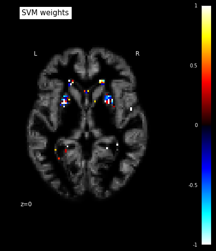

```python
from ipywidgets import interact, interact_manual
import ipywidgets as widgets

slider = widgets.IntSlider(min=-100,max=100,step=5,value=0)

@interact_manual(z_slice=slider)
def plot_svm_weights(z_slice):
    fig = plt.figure(figsize=(5.5, 7.5), facecolor='k')
    display = plot_stat_map(weight_img,
                            bg_img=bg_filename,
                            display_mode='z',
                            cut_coords=[z_slice],
                            figure=fig,
                            vmax=1)
    display.title('SVM weights', y=1.2)
    show()
plot_svm_weights(0)
show()
```